## Instructions

You can assume that your audience is the CEO and CFO of Budweiser (your client) and that they only have had one class in statistics and have indicated that you cannot take more than 7 minutes of their time. 20% of your grade will be based on the presentation.

They have hired you to address the 9 questions / items described in the next section. Beyond those general questions you may and should speculate / anticipate what may be of interest to them.

## Deliverables

1. A GitHub repository (Due Saturday March 7th 11:59pm CST

The GitHub repo should contain the following items and a link to the GitHub repo should be placed on a Word Doc (or PDF) and submitted to 2DS for Unit 8.

The final repo which will be checked after 11:59pm CST March 7th should contain:

1. An RMarkdown file containing the following:
1. The introduction needs to be written as if you are presenting the work to the CEO and CFO of Budweiser (your client) and that they only have had one class in statistics. If it sounds like a student presentation, that is not acceptable. You may assume that the CEO and CFO gave you the data and gave you the directive to report any interesting finding that you may uncover through your analysis.
2. Briefly explain the purpose of the code. The explanations should appear as a sentence or two before or after the code chunk. Even though you will not be hiding the code chunks (so that I can see the code), you need to assume that the client can’t see them.
3. Use R to address the 9 questions / items below:
1. How many breweries are present in each state?
2. Merge beer data with the breweries data. Print the first 6 observations and the last six observations to check the merged file. (RMD only, this does not need to be included in the presentation or the deck.)
3. Address the missing values in each column.
4. Compute the median alcohol content and international bitterness unit for each state. Plot a bar chart to compare.
5. Which state has the maximum alcoholic (ABV) beer? Which state has the most bitter (IBU) beer?
6. Comment on the summary statistics and distribution of the ABV variable.
7. Is there an apparent relationship between the bitterness of the beer and its alcoholic content? Draw a scatter plot. Make your best judgment of a relationship and EXPLAIN your answer.
8. Budweiser would also like to investigate the difference with respect to IBU and ABV between IPAs (India Pale Ales) and other types of Ale (any beer with “Ale” in its name other than IPA). You decide to use KNN classification to investigate this relationship. Provide statistical evidence one way or the other. You can of course assume your audience is comfortable with percentages … KNN is very easy to understand conceptually.

In addition, while you have decided to use KNN to investigate this relationship (KNN is required) you may also feel free to supplement your response to this question with any other methods or techniques you have learned. Creativity and alternative solutions are always encouraged.

9. Knock their socks off! Find one other useful inference from the data that you feel Budweiser may be able to find value in. You must convince them why it is important and back up your conviction with appropriate statistical evidence.

Directives on RMD File: i. Give clear, explicit answers to the questions. Just the code to answer the questions is not nearly enough, even if the code is correct and gives the correct answer. You must state the answer in a complete sentence outside the code chunk.

2. Conclusion to the project. Summarize your findings from this exercise. The file must be readable in GitHub. In other words, don’t forget to keep the md file!!
2. Knit HTML file.  
   In fact, you will also upload the knit html file to GitHub as well. This will allow for plots and tables to supplement your answers (part e) to the 7 questions below. You are already making an Rmd file, we should take advantage of it and knit a nice presentation of the project!
3. Codebook, Both CSV files and a ReadMe.md The Readme file describes the purpose of the project and codebook. The repo can be structured however you like, but it should make sense and be easily navigated.
4. PPT Slides Described more below and should have the link to your You Tube presentation … described further below as well.)

B. UNIT 8 Live Session: EDA Each team will need to meet with the professor and present their EDA in Unit 8. It is up to the teams and the professor when and how to set up these meetings. They may be during the schedule live session time, but given time constraints, some teams will need to schedule times outside of their scheduled live session time. With that said, these are one on one meetings between each team and the professor. Your only scheduled time commitment in Unit 8 is to attend this 10ish minute meeting with your professor. The rest of the time is reserved to work on your project with your partner. Your goal is to present your EDA (Answers to Questions 1,3,4,5,6,7). At this point, teams should have presentation quality slides and presentation prepared. Responses to each of the questions listed above should be prepared and addressed in this meeting.

The grade for this portion is based on the slide deck and the presentation. If the team is prepared and delivers a well-practiced presentation it should be easy to earn close to a 100% here.

2. Unit 9 Live Session: Q & A.  
   During Live Session for Unit 9, the professor will be available for a live Q & A about the project / presentation. Attendance at this live session is not required (attendance is optional). NOTE ABOUT POWERPOINT … You may use the same powerpoint or develop them separately. I would imagine that even if you develop the powerpoint together that each student’s final powerpoint will be a little different just based on individual presentation style. Everyone has their own unique style and delivery.

C. Final YouTube Video Each team member will need to record and upload to YouTube a 7-minute or less presentation of your findings. At this point you should know your presentation backwards and forwards. If you trip up too much in your recording, you should start over until you have a very polished presentation that does not exceed 7 minutes.

To record you can download Camtasia (free trial) which is a video software available at https://www.techsmith.com/video-editor.html or use your preferred screen capture software (like QuickTime if you have a Mac.) The presentation slides that include a link to your video should be in the Case Study Github repo as well as on the Google Doc provided by your professor. The goal is to communicate the findings of the project in a clear, concise and scientific manner. Also, uploading to YouTube is not difficult. Here is a YouTube video to help: https://www.youtube.com/watch?v=VtF2AgFSLAw Your professor will make the Google Doc link available to everyone in the class so that your peers can benefit from your work and so that you can benefit from theirs. Student’s presentation links will be available for a week at which time you may take your video off of YouTube if you wish.

## Collaboration and Peer Review

This will be a team project. We expect that all team members will do equal work and give their best to advance the knowledge of both themselves and their teammate. All members will need to push, add, commit, and pull to GitHub. This is a collaborative project, be sure and communicate early and often; mutual respect is key.

You will be providing two peer reviews that will be submitted to 2DS in Unit 8 and Unit 9 under: Project 1: EDA and Peer Review (by Saturday Feb 29 11:59pm / Unit 8) and Project 1: Final Documentation, Presentation and Peer Review Assignment (by Saturday March 7 11:59pm / Unit 9) . See the Rubric for detailed information on the peer review.

## EDA:

Questions 1,3,4,5,6,7

## Load Libraries

```r
#install.packages("vctrs")
library(vctrs)
library(qwraps2)
```

```r
library(tidyverse) # super library that loads dplyr, ggplot2, lubridate, tidyr, stringr, etc.
library(DataExplorer) # shows missing values by bar and percentage.
library(maps) # used for heat map
library(openintro) # used to convert state abbreviation to full state name
library(gdata)
library(mapdata)
library(mime)
library(treemap) # used for displaying hierarchical data as a set of nested rectangles
library(VIM)
library(inspectdf) #usd for columnwise summary, comparison and visualisation of data frames
library(GGally) # used for ggpairs ()to plot multiple variables, combines different plots into matrix
library(fiftystater)# use to plot 50-state choropleth thematic maps with ggplot2 in R
library(ggthemes)# used for adding some extra themes, geoms, and scales for 'ggplot2
library(gridExtra)
library(class)
library(broom)
library(caret)
theme_set(theme_classic())
```

## Load Data

```r
setwd("C:/Users/thads/OneDrive/SMU Data Science/DS6306/DDS6306-Group-Project-1")

beers_df <- read.csv(file.choose())
breweries_df <-
  read.csv(file.choose()) #store breweries data under breweries_df dataframe
```

## Inspect the data

```r
#View(beers_df) # view the complete dataframe
names(beers_df) # view the variable names
```

```
## [1] "Name"       "Beer_ID"    "ABV"        "IBU"        "Brewery_id"
## [6] "Style"      "Ounces"
```

```r
dim(beers_df) # view the dimensions of the data
```

```
## [1] 2410    7
```

```r
str(beers_df) # view the structure of the data
```

```
## 'data.frame':    2410 obs. of  7 variables:
##  $ Name      : Factor w/ 2305 levels "#001 Golden Amber Lager",..: 1638 577 1705 1842 1819 268 1160 758 1093 486 ...
##  $ Beer_ID   : int  1436 2265 2264 2263 2262 2261 2260 2259 2258 2131 ...
##  $ ABV       : num  0.05 0.066 0.071 0.09 0.075 0.077 0.045 0.065 0.055 0.086 ...
##  $ IBU       : int  NA NA NA NA NA NA NA NA NA NA ...
##  $ Brewery_id: int  409 178 178 178 178 178 178 178 178 178 ...
##  $ Style     : Factor w/ 100 levels "","Abbey Single Ale",..: 19 18 16 12 16 80 18 22 18 12 ...
##  $ Ounces    : num  12 12 12 12 12 12 12 12 12 12 ...
```

```r
head(beers_df, n = 5) # view the first 5 records
```

```
##                  Name Beer_ID   ABV IBU Brewery_id
## 1            Pub Beer    1436 0.050  NA        409
## 2         Devil's Cup    2265 0.066  NA        178
## 3 Rise of the Phoenix    2264 0.071  NA        178
## 4            Sinister    2263 0.090  NA        178
## 5       Sex and Candy    2262 0.075  NA        178
##                            Style Ounces
## 1            American Pale Lager     12
## 2        American Pale Ale (APA)     12
## 3                   American IPA     12
## 4 American Double / Imperial IPA     12
## 5                   American IPA     12
```

```r
tail(beers_df, n = 5) # view the last 5 records
```

```
##                      Name Beer_ID   ABV IBU Brewery_id                    Style
## 2406            Belgorado     928 0.067  45        425              Belgian IPA
## 2407        Rail Yard Ale     807 0.052  NA        425 American Amber / Red Ale
## 2408      B3K Black Lager     620 0.055  NA        425              Schwarzbier
## 2409  Silverback Pale Ale     145 0.055  40        425  American Pale Ale (APA)
## 2410 Rail Yard Ale (2009)      84 0.052  NA        425 American Amber / Red Ale
##      Ounces
## 2406     12
## 2407     12
## 2408     12
## 2409     12
## 2410     12
```

```r
summary(beers_df) # view basic model data i.e. min, max, mdedium, mean, etc.
```

```
##                      Name         Beer_ID            ABV
##  Nonstop Hef Hop       :  12   Min.   :   1.0   Min.   :0.00100
##  Dale's Pale Ale       :   6   1st Qu.: 808.2   1st Qu.:0.05000
##  Oktoberfest           :   6   Median :1453.5   Median :0.05600
##  Longboard Island Lager:   4   Mean   :1431.1   Mean   :0.05977
##  1327 Pod's ESB        :   3   3rd Qu.:2075.8   3rd Qu.:0.06700
##  Boston Lager          :   3   Max.   :2692.0   Max.   :0.12800
##  (Other)               :2376                    NA's   :62
##       IBU           Brewery_id                               Style
##  Min.   :  4.00   Min.   :  1.0   American IPA                  : 424
##  1st Qu.: 21.00   1st Qu.: 94.0   American Pale Ale (APA)       : 245
##  Median : 35.00   Median :206.0   American Amber / Red Ale      : 133
##  Mean   : 42.71   Mean   :232.7   American Blonde Ale           : 108
##  3rd Qu.: 64.00   3rd Qu.:367.0   American Double / Imperial IPA: 105
##  Max.   :138.00   Max.   :558.0   American Pale Wheat Ale       :  97
##  NA's   :1005                     (Other)                       :1298
##      Ounces
##  Min.   : 8.40
##  1st Qu.:12.00
##  Median :12.00
##  Mean   :13.59
##  3rd Qu.:16.00
##  Max.   :32.00
##
```

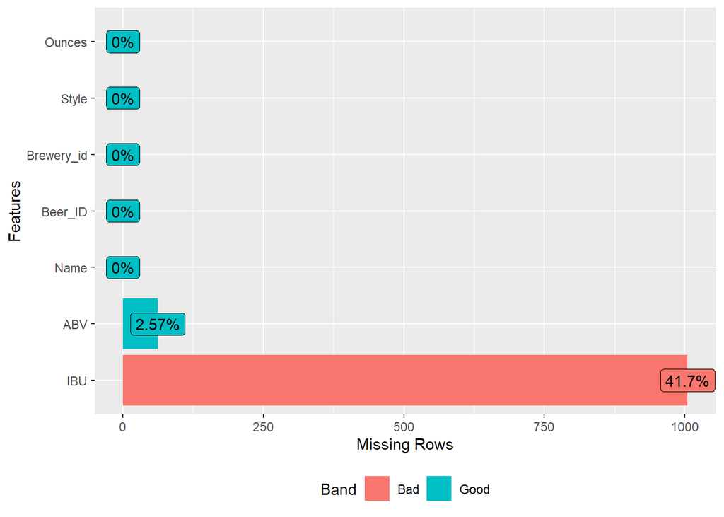

```r
plot_missing(beers_df) #shows missing values using package DataExplorer
```

```r
names(breweries_df) # view the variable names
```

```
## [1] "Brew_ID" "Name"    "City"    "State"
```

```r
dim(breweries_df) # view the dimensions of the data
```

```
## [1] 558   4
```

```r
str(breweries_df) # view the structure of the data
```

```
## 'data.frame':    558 obs. of  4 variables:
##  $ Brew_ID: int  1 2 3 4 5 6 7 8 9 10 ...
##  $ Name   : Factor w/ 551 levels "10 Barrel Brewing Company",..: 355 12 266 319 201 136 227 477 59 491 ...
##  $ City   : Factor w/ 384 levels "Abingdon","Abita Springs",..: 228 200 122 299 300 62 91 48 152 136 ...
##  $ State  : Factor w/ 51 levels " AK"," AL"," AR",..: 24 18 20 5 5 41 6 23 23 23 ...
```

```r
head(breweries_df, n = 5) # view the first 5 records
```

```
##   Brew_ID                      Name          City State
## 1       1        NorthGate Brewing    Minneapolis    MN
## 2       2 Against the Grain Brewery    Louisville    KY
## 3       3  Jack's Abby Craft Lagers    Framingham    MA
## 4       4 Mike Hess Brewing Company     San Diego    CA
## 5       5   Fort Point Beer Company San Francisco    CA
```

```r
tail(breweries_df, n = 5) # view the last 5 records
```

```
##     Brew_ID                          Name          City State
## 554     554           Covington Brewhouse     Covington    LA
## 555     555               Dave's Brewfarm        Wilson    WI
## 556     556         Ukiah Brewing Company         Ukiah    CA
## 557     557       Butternuts Beer and Ale Garrattsville    NY
## 558     558 Sleeping Lady Brewing Company     Anchorage    AK
```

```r
summary(breweries_df) # view basic model data i.e. min, max, mdedium, mean, etc.
```

```
##     Brew_ID                           Name           City         State
##  Min.   :  1.0   Blackrocks Brewery     :  2   Portland: 17    CO    : 47
##  1st Qu.:140.2   Blue Mountain Brewery  :  2   Boulder :  9    CA    : 39
##  Median :279.5   Lucette Brewing Company:  2   Chicago :  9    MI    : 32
##  Mean   :279.5   Oskar Blues Brewery    :  2   Seattle :  9    OR    : 29
##  3rd Qu.:418.8   Otter Creek Brewing    :  2   Austin  :  8    TX    : 28
##  Max.   :558.0   Sly Fox Brewing Company:  2   Denver  :  8    PA    : 25
##                  (Other)                :546   (Other) :498   (Other):358
```

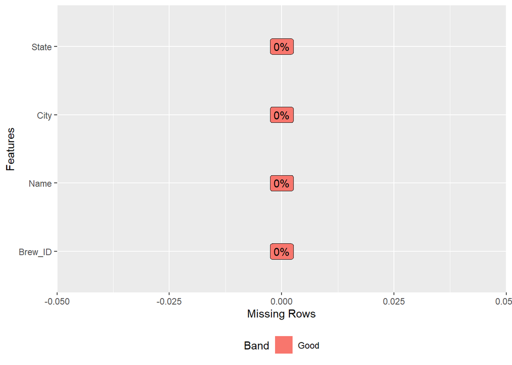

```r
plot_missing(breweries_df) #shows missing values using package DataExplorer
```

```r
brewery_dupes <-
  as.character(breweries_df[which(duplicated(as.character(breweries_df$Name))), "Name"]) # Check for duplicates  breweries names
breweries_df %>% filter(Name == "Summit Brewing Company")  # Brew_ID, City (St. Paul, St Paul)
```

```
##   Brew_ID                   Name     City State
## 1      59 Summit Brewing Company St. Paul    MN
## 2     139 Summit Brewing Company  St Paul    MN
```

```r
breweries_df %>% filter(Name == "Lucette Brewing Company") # Brew_ID, City (Menominee, Menominie)
```

```
##   Brew_ID                    Name      City State
## 1     378 Lucette Brewing Company Menominee    WI
## 2     457 Lucette Brewing Company Menominie    WI
```

```r
breweries_df$City <-
  str_replace_all(breweries_df$City, "St. Paul", "St Paul") ## sync spelling
breweries_df$City <-
  str_replace_all(breweries_df$City, "Menominee", "Menominie") ## sync spelling
```

## Sanitize Variable Names In Data Sets

```r
options(show.error.messages = FALSE)
try(breweries_df <-
      rename(breweries_df, Brewery_id = Brew_ID))
# changed col or variable name to match both data set.
try(breweries_df <-
      rename(breweries_df, Brewery_Name = Name))
#changed col or variable name
try(beers_df <-
      rename(beers_df, Beer_Name = Name))
#changed col or variable name
options(show.error.messages = TRUE)
```

## Get mapping information

```r
states_df <- map_data("state") # get US states and their coordinates
```

## Question 1:

How many breweries are present in each state?

```r
brewery_states_df <-
  breweries_df %>% group_by(State) %>% distinct(Brewery_id) # grouping by State using dplyr package
brewery_count <- aggregate(Brewery_id ~ State, breweries_df, length)
names(brewery_count) <-
  c("State", "Breweries") # replace the col names

brewery_count$State <-
  trim(brewery_count$State, recode.factor = TRUE) # trim white spaces
brewery_count$region <-
  tolower(abbr2state(brewery_count$State)) # change all region to lower case

brewery_map_df <-
  left_join(states_df, brewery_count, by = "region") # merge state_df and brewery count by region to plot all the state in us map.
state_center <-
  aggregate(
    cbind(long, lat) ~ State,
    data = brewery_map_df,
    FUN = function(x)
      mean(range(x))
  ) # combine lat and long of same repeated state into one long and lat
state_center_region <- brewery_map_df %>% group_by(State) %>%
  summarize_at(vars(long, lat), ~ mean(range(.)))
all.equal(state_center, as.data.frame(state_center_region))
```

```
## [1] TRUE
```

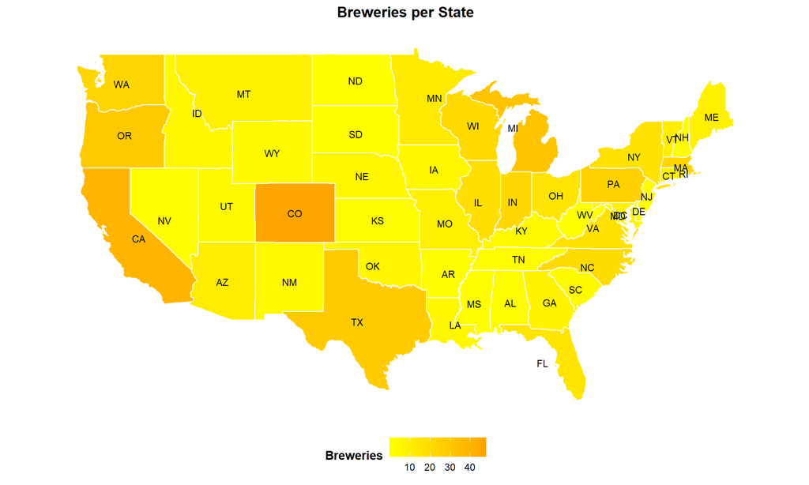

```r
library(mapproj) # for coord_map function - projects map in spherical into 2D
ggplot(data = brewery_map_df) +
  geom_path(aes(x = long, y = lat, group = group), color = "white") +
  geom_polygon(aes(
    x = long,
    y = lat,
    group = group,
    fill = Breweries # fill the map by breweries type by state and total breweries.
  ), color = "white") +
  coord_map() +
  scale_fill_gradient(low = "yellow" , high = "orange") + #  create label color gradient
  geom_text(aes(x = long, y = lat, label = State),
            #geom_text - adds name of State into the map
            data = state_center,
            size = 3) +
  ggtitle("Breweries per State") +
  theme(
    axis.text = element_blank(),
    axis.line =  element_blank(),
    axis.ticks =  element_blank(),
    panel.border = element_blank(),
    panel.grid = element_blank(),
    axis.title = element_blank(),
    legend.position = "bottom",
    legend.title = element_text(face = "bold"),
    legend.direction = "horizontal",
    plot.title = element_text(face = "bold",
                              hjust = 0.5)
  ) # element_black : remove x- axis, y-axis lines, labels, title. Formate legneds and plot text
```

## Question 2:

Merge beer data with the breweries data. Print the first 6 observations and the last six observations to check the merged file. (RMD only, this does not need to be included in the presentation or the deck.)

```r
beer_brewery_merged_df <-
  full_join(beers_df, breweries_df, by = "Brewery_id") # merge by  full_join  using key word  Brewery_id
head(beer_brewery_merged_df, n = 5) # view the first 5 records
```

```
##             Beer_Name Beer_ID   ABV IBU Brewery_id
## 1            Pub Beer    1436 0.050  NA        409
## 2         Devil's Cup    2265 0.066  NA        178
## 3 Rise of the Phoenix    2264 0.071  NA        178
## 4            Sinister    2263 0.090  NA        178
## 5       Sex and Candy    2262 0.075  NA        178
##                            Style Ounces              Brewery_Name City State
## 1            American Pale Lager     12 10 Barrel Brewing Company Bend    OR
## 2        American Pale Ale (APA)     12       18th Street Brewery Gary    IN
## 3                   American IPA     12       18th Street Brewery Gary    IN
## 4 American Double / Imperial IPA     12       18th Street Brewery Gary    IN
## 5                   American IPA     12       18th Street Brewery Gary    IN
```

```r
tail(beer_brewery_merged_df, n = 5) # view the last 5 records
```

```
##                 Beer_Name Beer_ID   ABV IBU Brewery_id                    Style
## 2406            Belgorado     928 0.067  45        425              Belgian IPA
## 2407        Rail Yard Ale     807 0.052  NA        425 American Amber / Red Ale
## 2408      B3K Black Lager     620 0.055  NA        425              Schwarzbier
## 2409  Silverback Pale Ale     145 0.055  40        425  American Pale Ale (APA)
## 2410 Rail Yard Ale (2009)      84 0.052  NA        425 American Amber / Red Ale
##      Ounces            Brewery_Name   City State
## 2406     12 Wynkoop Brewing Company Denver    CO
## 2407     12 Wynkoop Brewing Company Denver    CO
## 2408     12 Wynkoop Brewing Company Denver    CO
## 2409     12 Wynkoop Brewing Company Denver    CO
## 2410     12 Wynkoop Brewing Company Denver    CO
```

## Question 3:

Address the missing values in each column.

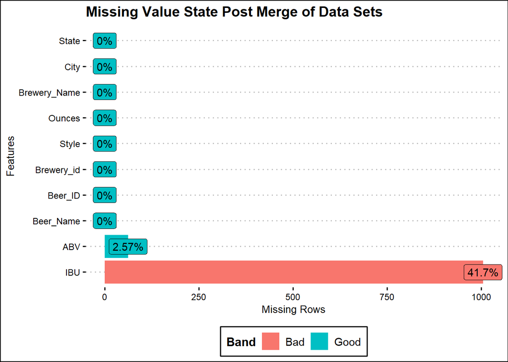

```r
plot_missing(beer_brewery_merged_df,
             title = "Missing Value State Post Merge of Data Sets",
             ggtheme = theme_clean())
```

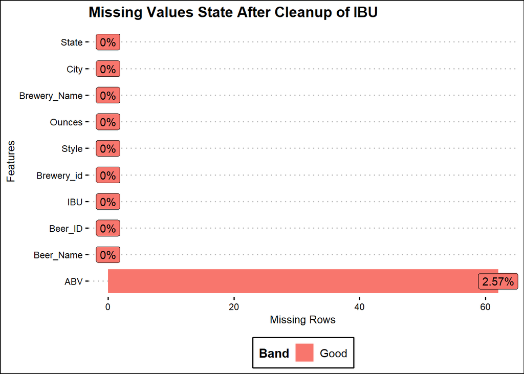

```r
#aggr(beer_brewery_merged_df, prop = FALSE, numbers = TRUE)
beer_brewery_merged_df <-
  beer_brewery_merged_df %>%  mutate(IBU = ifelse(is.na(IBU) |
                                                    is.na(ABV), 0, IBU)) # replace all empty and NA value by zero. Replce New IBU with New IBU using mutate()

plot_missing(beer_brewery_merged_df,
             title = "Missing Values State After Cleanup of IBU",
             ggtheme = theme_clean())
```

```r
# code added to drop ABV NA's
beer_brewery_merged_df <- beer_brewery_merged_df %>% drop_na(ABV)
```

## Question 4:

Compute the median alcohol content and international bitterness unit for each state. Plot a bar chart to compare.

```r
## Calculate IBU and ABV median by state
ibu_median <-
  beer_brewery_merged_df %>% group_by(State) %>% summarise_each(funs(median), median = IBU) %>% arrange(median)
head(ibu_median, 5) # print first 5 IBU median
```

```
## # A tibble: 5 x 2
##   State median
##   <fct>  <dbl>
## 1 " AR"      0
## 2 " CT"      0
## 3 " GA"      0
## 4 " IL"      0
## 5 " MD"      0
```

```r
tail(ibu_median, 5)# print last 5 IBU median
```

```
## # A tibble: 5 x 2
##   State median
##   <fct>  <dbl>
## 1 " MN"   38
## 2 " AL"   39.5
## 3 " MS"   45
## 4 " DE"   52
## 5 " WV"   57.5
```

```r
abv_median <-
  beer_brewery_merged_df %>% na.omit() %>% group_by(State) %>% summarise_each(funs(median), median = ABV) %>% arrange(median) # group dataset by state and arrange them and calculate median. Apply function to ABV column.
head(abv_median, 5)
```

```
## # A tibble: 5 x 2
##   State median
##   <fct>  <dbl>
## 1 " UT"  0.04
## 2 " NJ"  0.046
## 3 " KS"  0.05
## 4 " ND"  0.05
## 5 " WY"  0.05
```

```r
tail(ibu_median, 5)
```

```
## # A tibble: 5 x 2
##   State median
##   <fct>  <dbl>
## 1 " MN"   38
## 2 " AL"   39.5
## 3 " MS"   45
## 4 " DE"   52
## 5 " WV"   57.5
```

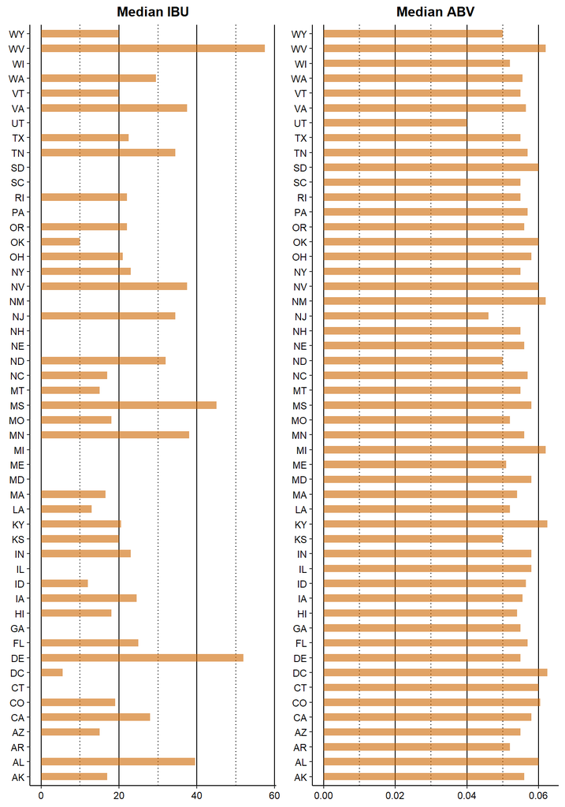

```r
p1 <-
  ggplot(ibu_median, aes(
    x = reorder(State),
    y = median,
    width = 0.5
  )) +
  geom_bar(
    stat = "identity",
    fill = "darkorange3",
    alpha = .6,
    width = .4
  ) +
  coord_flip() +
  ggtitle("IBU Median") +
  theme(
    panel.grid.major.y = element_blank(),
    plot.title = element_text(face = "bold", size = 12),
    axis.title = element_blank()
  ) + theme(
    panel.grid.major = element_line(colour = "black"),
    # crate line to differentiate the bar
    panel.grid.minor = element_line(colour = "black",
                                    linetype = "dotted"),
    axis.text = element_text(colour = "black"),
    plot.title = element_text(hjust = 0.5),
    # align title to the middel of chart
    legend.position = "none"
  ) + labs(title = "Median IBU")

p2 <-
  ggplot(abv_median, aes(
    x = reorder(State),
    # arrange or reoder the factor level state based on ABU value
    y = median,
    width = 0.5
  )) +
  geom_bar(
    stat = "identity",
    fill = "darkorange3",
    alpha = .6,
    width = .4
  ) +
  coord_flip() +
  ggtitle("ABV Median") +
  theme(
    panel.grid.major.y = element_blank(),
    plot.title = element_text(face = "bold", size = 12),
    axis.title = element_blank()
  ) + theme(
    panel.grid.major = element_line(colour = "black"),
    panel.grid.minor = element_line(colour = "black",
                                    linetype = "dotted"),
    axis.text = element_text(colour = "black"),
    plot.title = element_text(hjust = 0.5),
    # align title to middle of chart
    legend.position = "none"
  ) + labs(title = "Median ABV")

grid.arrange(p1, p2, ncol = 2) # puts the two graph side by side
```

## Question 5:

Which state has the maximum alcoholic (ABV) beer? Which state has the most bitter (IBU) beer?

```r
# find max IBU of beer and arrange by top 10
ibu_max <-
  beer_brewery_merged_df %>% group_by(State) %>% summarise_each(funs(max), ibumax = IBU) %>% arrange(-ibumax)
head(ibu_max, 5)
```

```
## # A tibble: 5 x 2
##   State ibumax
##   <fct>  <dbl>
## 1 " OR"    138
## 2 " VA"    135
## 3 " MA"    130
## 4 " OH"    126
## 5 " MN"    120
```

```r
tail(ibu_max, 5)
```

```
## # A tibble: 5 x 2
##   State ibumax
##   <fct>  <dbl>
## 1 " TN"     61
## 2 " LA"     60
## 3 " DE"     52
## 4 " AR"     39
## 5 " SD"      0
```

```r
ibu_top <-
  ibu_max %>% top_n(5, ibumax) # print top 6 state with highest IBU.
ibu_top <- ibu_top[order(-ibu_top$ibumax),]

# find ABV max grouped by state
abv_max <-
  beer_brewery_merged_df %>% na.omit() %>% group_by(State) %>% summarise_each(funs(max), abvmax = ABV) %>% arrange(-abvmax)
head(abv_max, 5)
```

```
## # A tibble: 5 x 2
##   State abvmax
##   <fct>  <dbl>
## 1 " CO"  0.128
## 2 " KY"  0.125
## 3 " IN"  0.12
## 4 " NY"  0.1
## 5 " CA"  0.099
```

```r
tail(abv_max, 5)
```

```
## # A tibble: 5 x 2
##   State abvmax
##   <fct>  <dbl>
## 1 " WV"  0.067
## 2 " NH"  0.065
## 3 " TN"  0.062
## 4 " AR"  0.061
## 5 " DE"  0.055
```

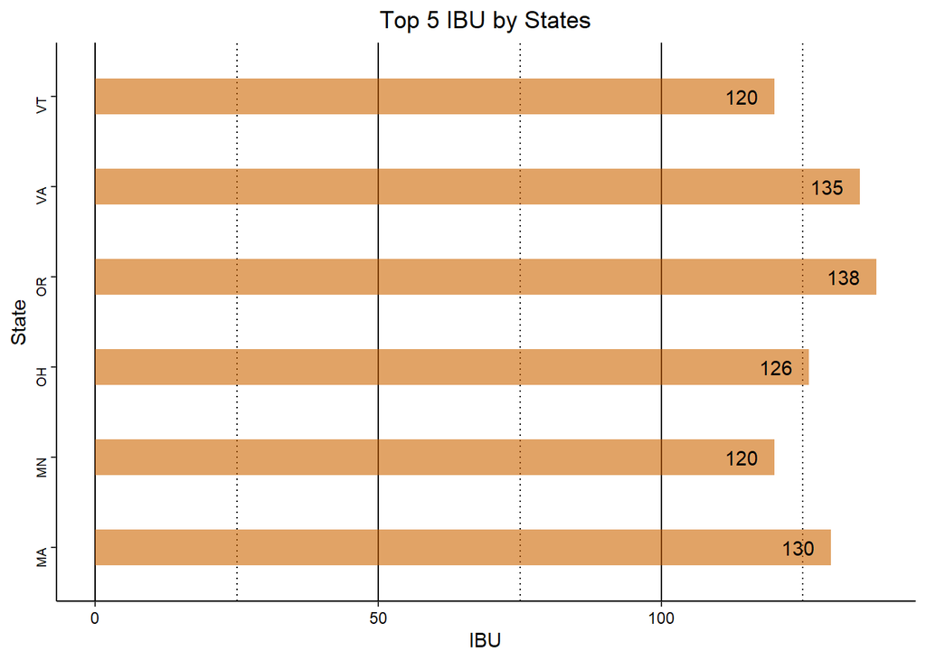

```r
abv_top <- abv_max %>% top_n(10, abvmax)
abv_top <- abv_top[order(-abv_top$abvmax),]

# plot top ten state representing IBU using bar plot
ggplot(ibu_top, aes(x = State, y = ibumax, fill = ibumax)) + geom_bar(
  stat = "identity",
  fill = "darkorange3",
  alpha = .6,
  width = .4
) + ggtitle("Top 5 IBU by States") +
  geom_text(aes(label = ibumax), hjust = 1.5) +
  theme(
    axis.text.y = element_text(size = rel(0.8), angle = 90),
    #the function rel() modifies the size relative to the base size. angle= 90: rotate terxt 90 deg
    panel.grid.major.y = element_blank(),
    panel.grid.major = element_line(colour = "black"),
    panel.grid.minor = element_line(colour = "black",
                                    linetype = "dotted"),
    axis.text = element_text(colour = "black"),
    plot.title = element_text(hjust = 0.5)
  ) +
  labs(x = "State", y = "IBU") +
  coord_flip() # flips the to horizontal form
```

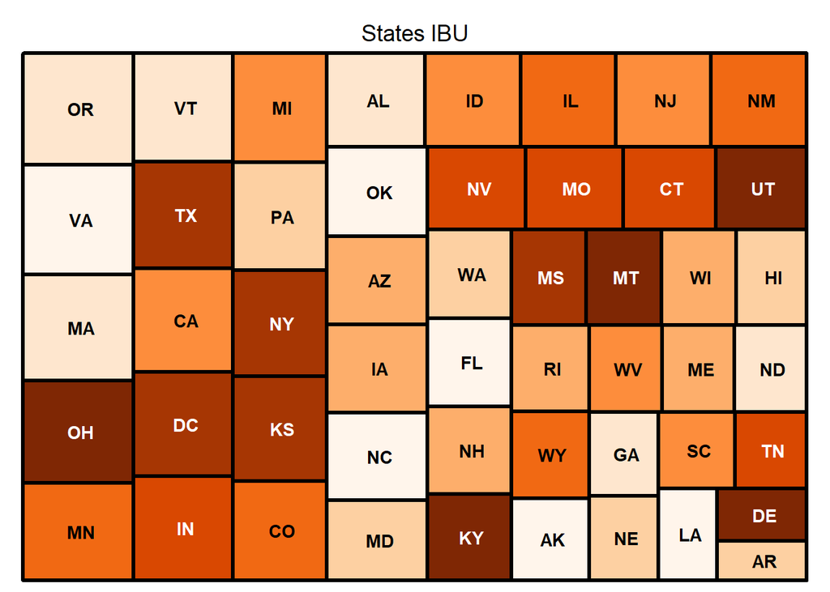

```r
#plot top ten state representing IBU using treemap formate
treemap(
  #A Treemap displays hierarchical data as a set of nested rectangles. Each state is represented by a rectangle, which area is proportional to its IBU value
  ibu_max,
  index = c("State", "ibumax"),
  #vector of column names
  vSize = "ibumax",
  #specifies the sizes of the rectangles (state)
  type = "index",
  #ype of the treemap, which determines how the rectangles (state) are colored
  palette = "Oranges",
  title = "States IBU",
  fontsize.title = 14 # treemap title font size
)
```

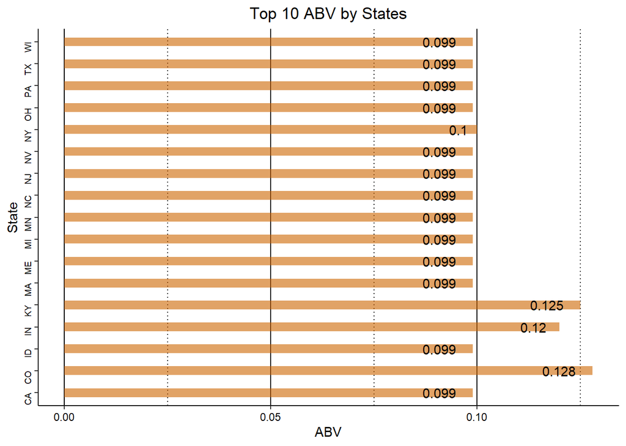

```r
# plot top ten state representing ABV using bar plot
ggplot(abv_top, aes(x = State, y = abvmax, fill = abvmax)) + geom_bar(
  stat = "identity",
  fill = "darkorange3",
  alpha = .6,
  width = .4
) + ggtitle("Top 10 ABV by States") +
  geom_text(aes(label = abvmax), hjust = 1.5) +
  theme(
    axis.text.y = element_text(size = rel(0.8), angle = 90),
    panel.grid.major.y = element_blank(),
    panel.grid.major = element_line(colour = "black"),
    panel.grid.minor = element_line(colour = "black",
                                    linetype = "dotted"),
    axis.text = element_text(colour = "black"),
    plot.title = element_text(hjust = 0.5)
  ) +
  labs(x = "State", y = "ABV") +
  coord_flip()
```

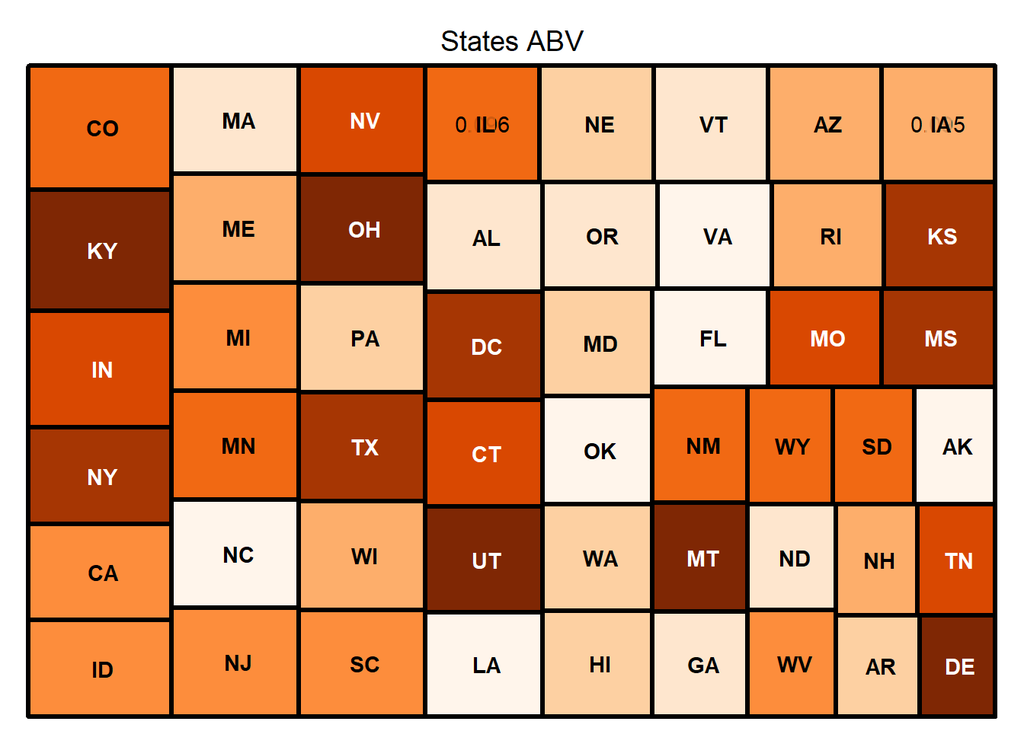

```r
#plot top ten state representing ABV using treempa formate
treemap(
  abv_max,
  index = c("State", "abvmax"),
  vSize = "abvmax",
  type = "index",
  palette = "Oranges",
  title = "States ABV",
  fontsize.title = 14
)
```

## Question 6:

Comment on the summary statistics and distribution of the ABV variable.

*IPA style beer is the predominant variety when ABV exceeds 0.06. This again indicates that IPA beer tends to have higher alcohol content than other variety.*

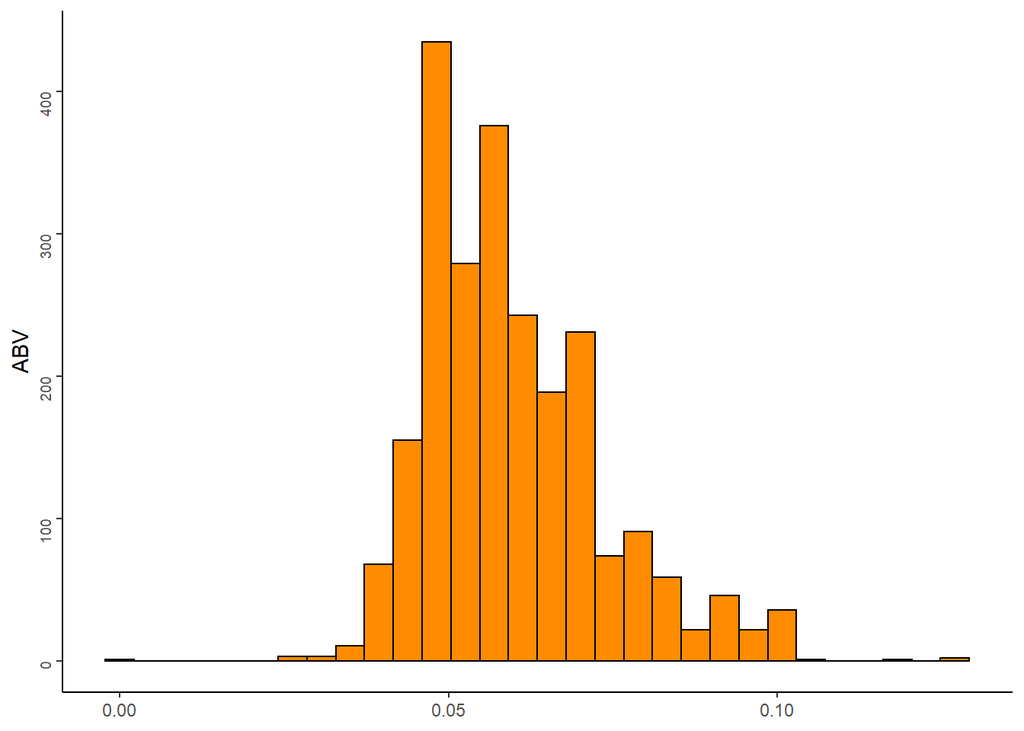

```r
# Create new column for IPA/Ale breakdown
beer_brewery_merged_df$Beer_Type <-
  ifelse(
    str_detect(beer_brewery_merged_df$Style, regex("IPA", ignore_case = TRUE)),
    "IPA",
    # using regular expression regex() to detect and ingnore the case of IPA
    ifelse(
      str_detect(beer_brewery_merged_df$Style, regex("Ale", ignore_case = TRUE)),
      "Ale",
      "Other"
    )
  )

##   Histogram showing the distribution of the ABV
beer_brewery_merged_df %>% ggplot(aes(x = ABV)) + geom_histogram(
  fill = "darkorange",
  color =
    "black",
  bins = 30,
  na.rm = TRUE
) + theme(axis.text.y = element_text(size = rel(0.8), angle = 90)) +
  labs(x = NULL, y = "ABV")
```

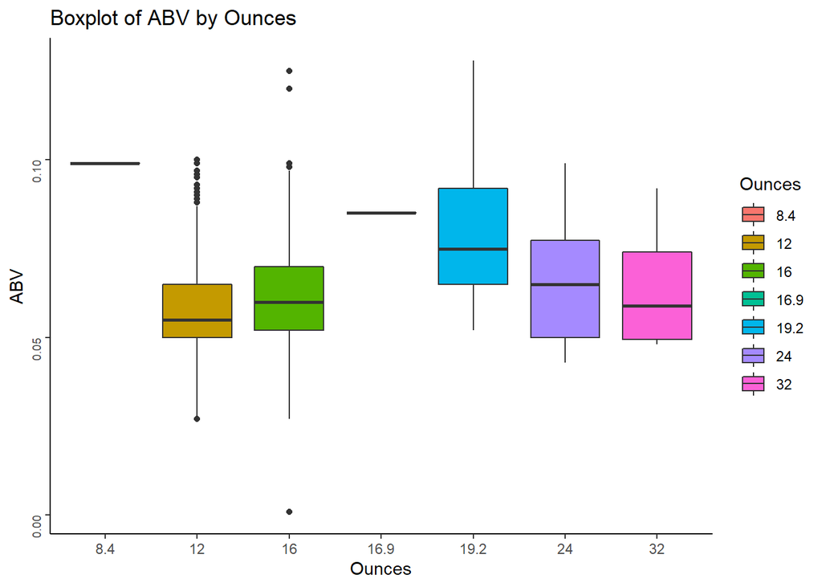

```r
##   Bloxplot showing the variation of ABV by ounce
beer_brewery_merged_df$Ounces = as.factor(beer_brewery_merged_df$Ounces)
beer_brewery_merged_df %>% ggplot(aes(y = ABV,
                                      x = Ounces, fill = Ounces)) + geom_boxplot(na.rm = TRUE) +
  theme(axis.text.y = element_text(size = rel(0.8), angle = 90)) +
  labs(x = "Ounces", y = "ABV") +
  ggtitle("Boxplot of ABV by Ounces")
```

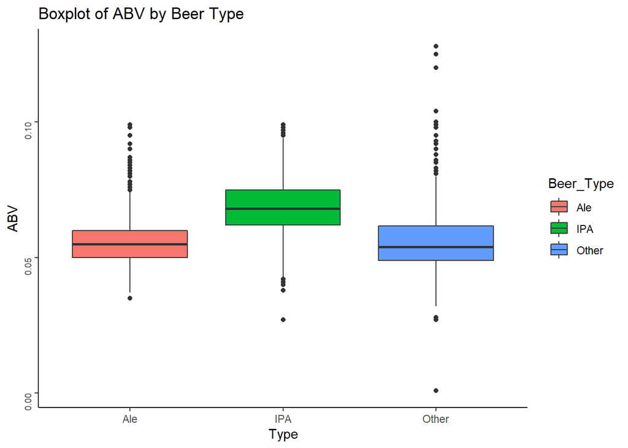

```r
# box plot showing the variation of ABV for three types: Ale, IPA and other
beer_brewery_merged_df %>% ggplot(aes(y = ABV,
                                      x = Beer_Type, fill = Beer_Type)) + geom_boxplot(na.rm = TRUE) +
  theme(axis.text.y = element_text(size = rel(0.8), angle = 90)) +
  labs(x = "Type", y = "ABV") +
  ggtitle("Boxplot of ABV by Beer Type")
```

```r
summary(beer_brewery_merged_df) # display summary statistic of data
```

```
##                   Beer_Name       Beer_ID            ABV
##  Nonstop Hef Hop       :  12   Min.   :   1.0   Min.   :0.00100
##  Dale's Pale Ale       :   6   1st Qu.: 827.8   1st Qu.:0.05000
##  Oktoberfest           :   6   Median :1463.5   Median :0.05600
##  Longboard Island Lager:   4   Mean   :1439.4   Mean   :0.05977
##  1327 Pod's ESB        :   3   3rd Qu.:2078.2   3rd Qu.:0.06700
##  Boston Lager          :   3   Max.   :2692.0   Max.   :0.12800
##  (Other)               :2314
##       IBU           Brewery_id                               Style
##  Min.   :  0.00   Min.   :  1.0   American IPA                  : 417
##  1st Qu.:  0.00   1st Qu.: 94.0   American Pale Ale (APA)       : 239
##  Median : 18.00   Median :206.0   American Amber / Red Ale      : 125
##  Mean   : 25.56   Mean   :231.3   American Blonde Ale           : 104
##  3rd Qu.: 42.00   3rd Qu.:366.0   American Double / Imperial IPA: 103
##  Max.   :138.00   Max.   :558.0   American Pale Wheat Ale       :  95
##                                   (Other)                       :1265
##   Ounces                         Brewery_Name      City
##  8.4 :   1   Brewery Vivant            :  60   Length:2348
##  12  :1484   Oskar Blues Brewery       :  42   Class :character
##  16  : 821   Sun King Brewing Company  :  36   Mode  :character
##  16.9:   1   Cigar City Brewing Company:  25
##  19.2:  15   Sixpoint Craft Ales       :  24
##  24  :  22   Hopworks Urban Brewery    :  23
##  32  :   4   (Other)                   :2138
##      State       Beer_Type
##   CO    : 250   Length:2348
##   CA    : 182   Class :character
##   MI    : 151   Mode  :character
##   IN    : 137
##   OR    : 125
##   TX    : 124
##  (Other):1379
```

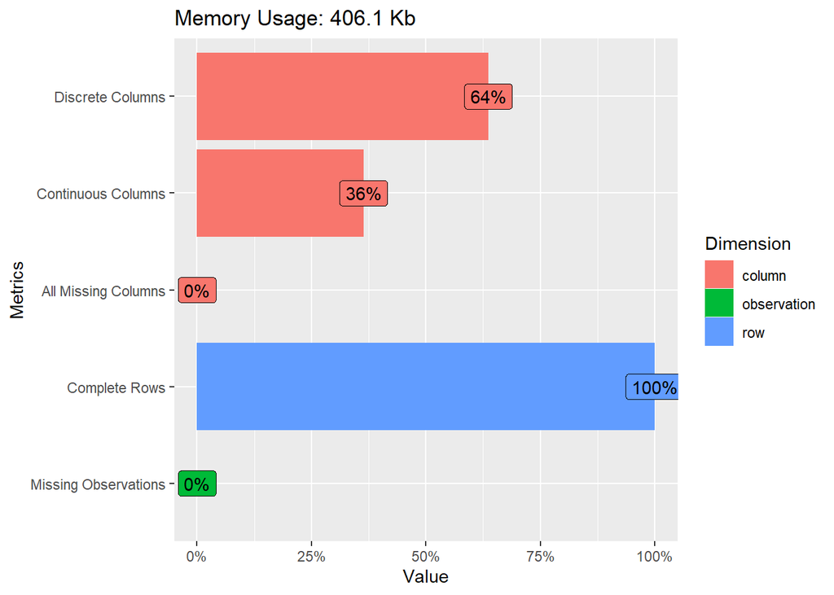

```r
plot_intro(beer_brewery_merged_df) # metrics display using DataExplorer package
```

```r
introduce(beer_brewery_merged_df) # Describe basic information in input data class like: # of col , # rows etc.
```

```
##   rows columns discrete_columns continuous_columns all_missing_columns
## 1 2348      11                7                  4                   0
##   total_missing_values complete_rows total_observations memory_usage
## 1                    0          2348              25828       415840
```

## Question 7:

Is there an apparent relationship between the bitterness of the beer and its alcoholic content? Draw a scatter plot. Make your best judgment of a relationship and EXPLAIN your answer.

*The point plot below illustrates what appears to a positive linear relationship between the ABV and IBU. The addition of line trend to the point plot below confirms the presence of a positive linear relationship between the ABV and IBU.*

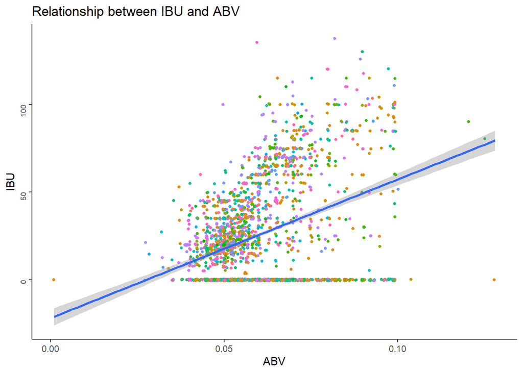

```r
# Scatter plot showing positive correlation between IBU and ABV
beer_brewery_merged_df %>% na.omit() %>% # use only data without NAs
  ggplot(aes(x = ABV, y = IBU)) +
  geom_point(aes(color = State), size = 1, position = "jitter") +
  geom_smooth(method = lm) +
  theme(axis.text.y = element_text(size = rel(0.8), angle = 90),
        legend.position = "none") +
  labs(x = "ABV", y = "IBU") +
  ggtitle("Relationship between IBU and ABV")
```

```r
#Pearson's correlation with original data
cor.test(beer_brewery_merged_df$IBU, beer_brewery_merged_df$ABV)
```

```
##
##  Pearson's product-moment correlation
##
## data:  beer_brewery_merged_df$IBU and beer_brewery_merged_df$ABV
## t = 19.228, df = 2346, p-value < 2.2e-16
## alternative hypothesis: true correlation is not equal to 0
## 95 percent confidence interval:
##  0.3334942 0.4033996
## sample estimates:
##       cor
## 0.3689686
```

```r
mod <-
  lm(beer_brewery_merged_df$IBU ~ beer_brewery_merged_df$ABV) # Create a linear model and save it into a variable mod.
summary(mod) # display summary statistic of our mod
```

```
##
## Call:
## lm(formula = beer_brewery_merged_df$IBU ~ beer_brewery_merged_df$ABV)
##
## Residuals:
##    Min     1Q Median     3Q    Max
## -79.49 -21.00  -1.81  18.84 110.05
##
## Coefficients:
##                            Estimate Std. Error t value Pr(>|t|)
## (Intercept)                 -21.688      2.519  -8.608   <2e-16 ***
## beer_brewery_merged_df$ABV  790.436     41.109  19.228   <2e-16 ***
## ---
## Signif. codes:  0 '***' 0.001 '**' 0.01 '*' 0.05 '.' 0.1 ' ' 1
##
## Residual standard error: 26.97 on 2346 degrees of freedom
## Multiple R-squared:  0.1361, Adjusted R-squared:  0.1358
## F-statistic: 369.7 on 1 and 2346 DF,  p-value: < 2.2e-16
```

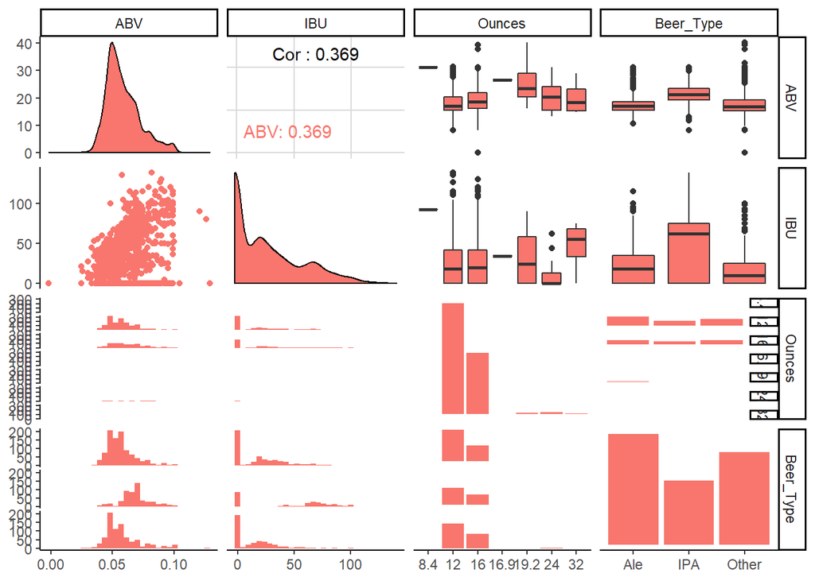

```r
# Plot GGpairs
beer_brewery_merged_df %>% na.omit() %>%
  select(ABV, IBU, Ounces, Beer_Type) %>%
  ggpairs(mapping = aes(color = "ABV"))
```

## Question 8

8. Budweiser would also like to investigate the difference with respect to IBU and ABV between IPAs (India Pale Ales) and other types of Ale (any beer with “Ale” in its name other than IPA). You decide to use KNN classification to investigate this relationship. Provide statistical evidence one way or the other. You can of course assume your audience is comfortable with percentages … KNN is very easy to understand conceptually.

In addition, while you have decided to use KNN to investigate this relationship (KNN is required) you may also feel free to supplement your response to this question with any other methods or techniques you have learned. Creativity and alternative solutions are always encouraged.

```r
# Filter out any beer style that isnt and IPA or an Ale.
beer_brewery_IPAandALE <-
  filter(beer_brewery_merged_df, grepl('IPA|Ale', Style))
beer_brewery_IPAandALE <- beer_brewery_IPAandALE[, -8]
# Create a new dataframe that only holds the ABV,IBU, and beer style.
beer_brewery_IPAandALE_subset <-
  select(beer_brewery_IPAandALE, ABV, IBU, Style)
beer_brewery_IPAandALE_subset$Style <-
  as.character(beer_brewery_IPAandALE_subset$Style) # change stye factor into character

# Normalize the Beer styles to IPA or ALE
# Loop below is used to iterate through each row and then to normalize the beer styles to simply say IPA or Ale.
for (i in 1:nrow(beer_brewery_IPAandALE_subset)) {
  if (is.na(str_match(beer_brewery_IPAandALE_subset[i, 3], ".Ale"))) {
    beer_brewery_IPAandALE_subset[i, 3] <- "IPA"
  } else {
    beer_brewery_IPAandALE_subset[i, 3] <- "ALE"

  }
}
# use KNN classification to investigate this relationship
# Provide statistical evidence. Your audience is comfortable with percentages.
# Select a random seed value
# A split of 70% to 30% will work with this dataset to create a useful training and test set.
set.seed(1234)
splitpale = .70
samplesplit <-
  sample(1:dim(beer_brewery_IPAandALE_subset)[1],
         round(splitpale * dim(beer_brewery_IPAandALE_subset)[1]))
```

# The following code separates the randomly selected values into the 70 to 30 split.

```r
trainIpa <- beer_brewery_IPAandALE_subset[samplesplit, ]
testIpa <- beer_brewery_IPAandALE_subset[-samplesplit, ]
# Using only the IBU and ABV values from both the training and test sets
# we are using the beer style as the class against which the knn will search.
knnipa <-
  knn(trainIpa[, c(1:2)],
      testIpa[, c(1:2)],
      trainIpa$Style,
      k = 14,
      prob = TRUE)
# The confusion matrix is used for calibrating the output of a model and examining all possible outcomes of the predictions
table(knnipa, testIpa$Style)
```

```
##
## knnipa ALE IPA
##    ALE 246  54
##    IPA  33 115
```

```r
ipamatrix = confusionMatrix(table(knnipa, testIpa$Style))
ipamatrix
```

```
## Confusion Matrix and Statistics
##
##
## knnipa ALE IPA
##    ALE 246  54
##    IPA  33 115
##
##                Accuracy : 0.8058
##                  95% CI : (0.7661, 0.8414)
##     No Information Rate : 0.6228
##     P-Value [Acc > NIR] : < 2e-16
##
##                   Kappa : 0.5763
##
##  Mcnemar's Test P-Value : 0.03201
##
##             Sensitivity : 0.8817
##             Specificity : 0.6805
##          Pos Pred Value : 0.8200
##          Neg Pred Value : 0.7770
##              Prevalence : 0.6228
##          Detection Rate : 0.5491
##    Detection Prevalence : 0.6696
##       Balanced Accuracy : 0.7811
##
##        'Positive' Class : ALE
##
```

# The below code will iterate through 100 values of k in order to hypertune the k parameter.